# plots for paper

Charles T. Gray

21/03/2019

The `varameta::` package proposes an alternative estimator for the variance of the sample median. This document generates the plots used in the paper associated with that estimator.

## preamble

```r
# packages used in this document
library(tidyverse)
library(metasim)
library(latex2exp)
```

```r
# set seed for reproducibility
set.seed(38)
```

In this document, we will make use of the `metasim::` package to generate some data.

### caption text

```r
caption_text <- paste0(
            "Coverage denotes the proportion of ",
            params$trials,
            " confidence intervals that contain the true median, or true log-ratio of medians, derived from random samples from exponential, log-normal, normal, and Pareto distributions. The vertical facets of the plot reflect simulation-level parameters for between-study variance $\\tau^2 \\in$ ",
            paste(params$tau2, collapse = ", "),
            " where simulations were performed with an assumption of no difference between the studies, aside from sampling error, $\\tau^2 = 0$, to a maximal between-study variance of $\\tau^2 =$ ",
            max(params$tau2),
            ".",
            collapse = ""
            )

# check this comes out nice
caption_text %>% knitr::asis_output()
```

Coverage denotes the proportion of 10 confidence intervals that contain the true median, or true log-ratio of medians, derived from random samples from exponential, log-normal, normal, and Pareto distributions. The vertical facets of the plot reflect simulation-level parameters for between-study variance $\tau^2 \in$ 0, 0.2, 0.4 where simulations were performed with an assumption of no difference between the studies, aside from sampling error, $\tau^2 = 0$, to a maximal between-study variance of $\tau^2 =$ 0.4.

## meta-analysis simulations

```r
meta_data <- metasims(
  probar = FALSE,
  trials = params$trials,
  k = params$k)
```

```r
ma_plot <- function(data, measure = "all") {
  df <- if (measure != "all") {
  data %>%
    filter(measure == measure)
  } else {
    data
  }

df  %>%
    mutate(
      median_ratio = as.character(median_ratio),
      distribution = map_chr(rdist, dist_name),
      measure = map_chr(measure, function(x) {
        if (x == "m")
          "median"
        else
          "log-ratio of medians"
      })
    ) %>%
    ggplot(aes(x = distribution, y = coverage)) +
    theme(axis.text.x = element_text(angle = 35, hjust = 1),
          plot.caption = element_text(hjust = 0)) +
    labs(x = "Distribution",
         y = "Coverage"
        )
}

cap_text <- "Simulation results for various distributions "
```

## median simulation plot

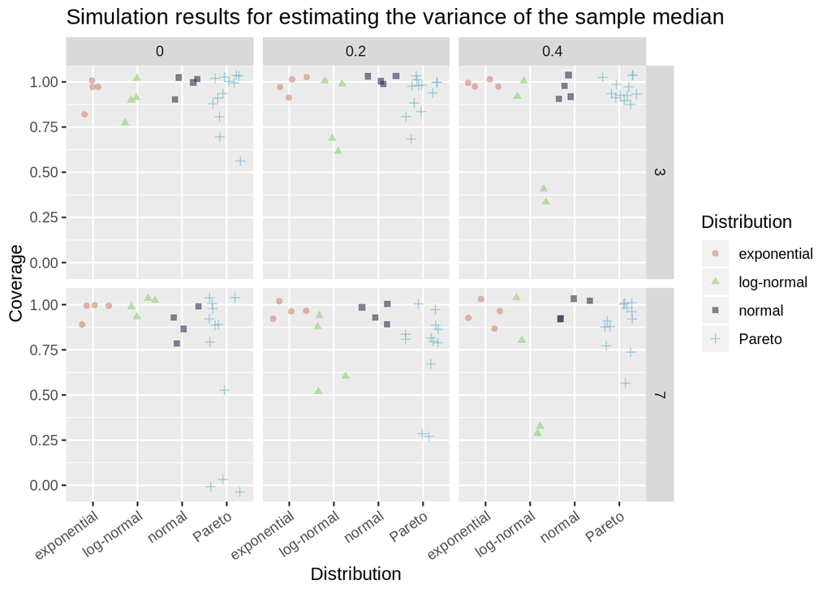

```r
meta_data %>%
ma_plot(measure = "m") +
  geom_point(
      aes(colour = distribution, shape = distribution),
      position = "jitter",
      alpha = 0.6
    ) +
    facet_grid(k ~ between_study_variation) +
  scale_shape_discrete(name = "Distribution") +
  hrbrthemes::scale_colour_ipsum(name = "Distribution") +
  labs(title = str_wrap("Simulation results for estimating the variance of the sample median"))
```

## log-ratio of medians simulation

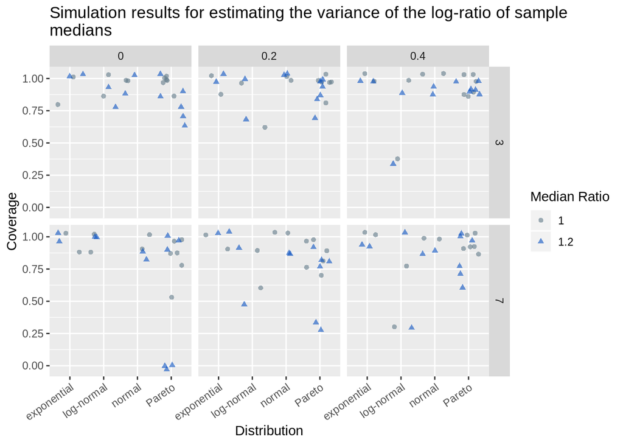

```r
meta_data %>%
ma_plot(measure = "lr") +
  geom_point(
      aes(shape = median_ratio, colour = median_ratio),
      position = "jitter",
      alpha = 0.6
    )  +
      facet_grid(k ~ between_study_variation) +
    scale_shape_discrete(name = "Median Ratio") +
    hrbrthemes::scale_colour_ft(name = "Median Ratio") +
  labs(title = str_wrap("Simulation results for estimating the variance of the log-ratio of sample medians"))
```

## distribution details

The `metasim::` package was developed for the use-case of `varameta::`, and thus these simulations use the inbuilt default parameter set.

```r
default_parameters %>%
  knitr::kable()
```

| dist | par |
| --- | --- |
| norm | list(mean = 67, sd = 0.3) |
| exp | list(rate = 2) |
| pareto | list(shape = 3, scale = 3) |
| pareto | list(shape = 2, scale = 1) |
| pareto | list(shape = 0.5, scale = 1) |
| lnorm | list(mean = 44, sd = 0.3) |

## single-study simulations

Although these results will be presented first in the paper, computationally this is a special use-case of `metasims` where `k = 1`.

```r
ss_data <- metasims(
  k = 1,
  trials = params$trials,
  probar = FALSE)
```

### single-study plot

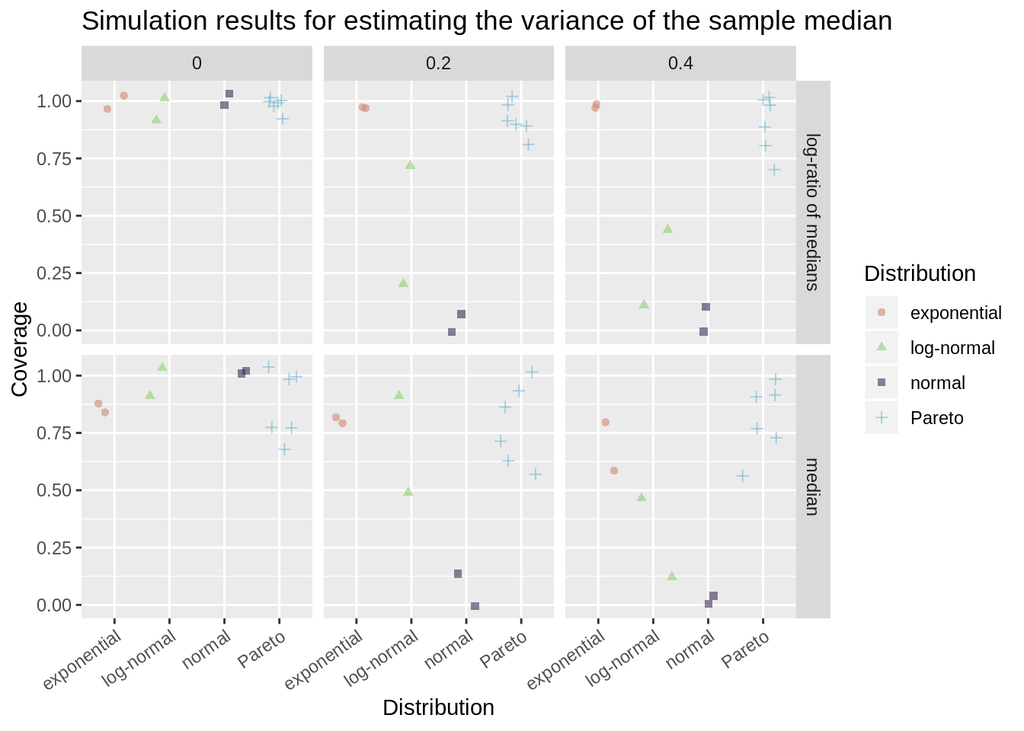

```r
ss_data %>%
  ma_plot() +
  geom_point(position = "jitter",
      aes(colour = distribution, shape = distribution),
      alpha = 0.6) +
  facet_grid(measure ~ between_study_variation) +
  scale_shape_discrete(name = "Distribution") +
  hrbrthemes::scale_colour_ipsum(name = "Distribution") +
  labs(title = str_wrap("Simulation results for estimating the variance of the sample median"))
```

Since I can’t get $\LaTeX$ to play nice with `str_wrap`, I’ll export the caption as text and the vis separately.